# mrgsolve evaluation

Justin Penzenstadler

March 3, 2016

## Set up

There is a protocol to install this package that must be followed exactly. Windows installations of R are not configured to install mrgsolve out of the box as source code. mrgsolve AND key dependencies (rcpp and RcppArmadillo) must be downloaded as source and compiled on the computer, rather than a typical installatin binary files. This convention is popular for linuxboxes with many different hardware configs.

## Protocol

**took JAP 3 hours to debug** derp - Download latest version of Rtools and run the exe https://cran.r-project.org/bin/windows/Rtools/ - - YOU MUST SPECIFY full installation - Must install MinGW-w64 32/64-bit toolchain to compile C, Fortran and C++ - - You must add both /rtools/bin and something else (forgot) to path - run install.packages(“Rcpp”, type=“source”) - run install.packages(“RcppArmadillo”, type=“source”) - run install.packages(“mrgsolve_0.5.11.tar.gz”, repos=NULL, type=“source”) - install dplyr/BH This could be a major impediment for casual users/noobs

# Part 1 - Vanco IV dosing

## Step 1 - specify a model

Options - Specify in editor as a .cpp code - specify as a string

```r
library(mrgsolve)
library(ggplot2)
#load base example model, then strip of data to use as template
cat(readLines("pkpdExample.cpp"), sep="\n")
```

```
## $PARAM
## KA = 1.2, CL = 1, VC = 25
## KIN = 100, KOUT = 2, EC50 = 4
##
## $CMT GUT CENT RESP
##
## $SET delta= 0.25
##
##
## $MAIN
## RESP_0 = KIN/KOUT;
##
## $ODE
## dxdt_GUT = -KA*GUT;
## dxdt_CENT = KA*GUT - (CL/VC)*CENT;
##
## double CP = CENT/VC;
## double INH = CP/(EC50+CP);
##
## dxdt_RESP = KIN*(1-INH) - RESP*KOUT;
##
## $CAPTURE CP
```

```r
##modify via editor for a 1cmpt IV - see text changes
cat(readLines("Vanco1cmpt.cpp"), sep="\n")
```

```
## $PARAM
## CL = 5.1, V = 59.86
##
## $CMT CENT
##
## $SET delta= 0.25
##
## $MAIN
##
## $ODE
## dxdt_CENT = - (CL/V)*CENT;
##
## double CP = CENT/V;
##
## $CAPTURE CP
```

```r
#Now you must complie using mread()
mod <- mread('Vanco1cmpt')
```

```
## Compiling Vanco1cmpt.cpp.cpp ...
```

```
## done.
```

```
## Loading: Vanco1cmpteac316d2bd3.dll
```

## Step 2 - specify dosing

```r
maint <- ev(amt= 1000, ii=12, addl = 1000)
```

## Step 3 - sim/plot

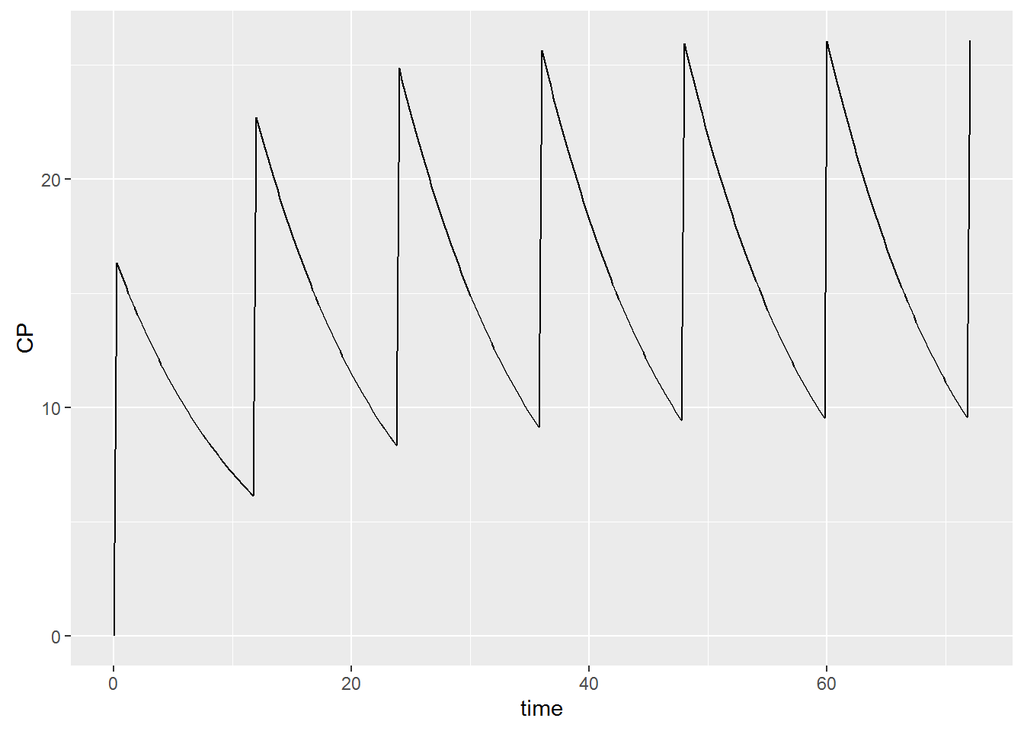

```r
bolussim <- mod %>% ev(maint) %>% mrgsim(end = 72) %>% as.data.frame



ggplot(bolussim, aes(x=time, y = CP)) + geom_line()
```

# Part 2 - IV Vanco 2 hour infusion

## Step 1

mod may be reused. Only need to respecify the dosing

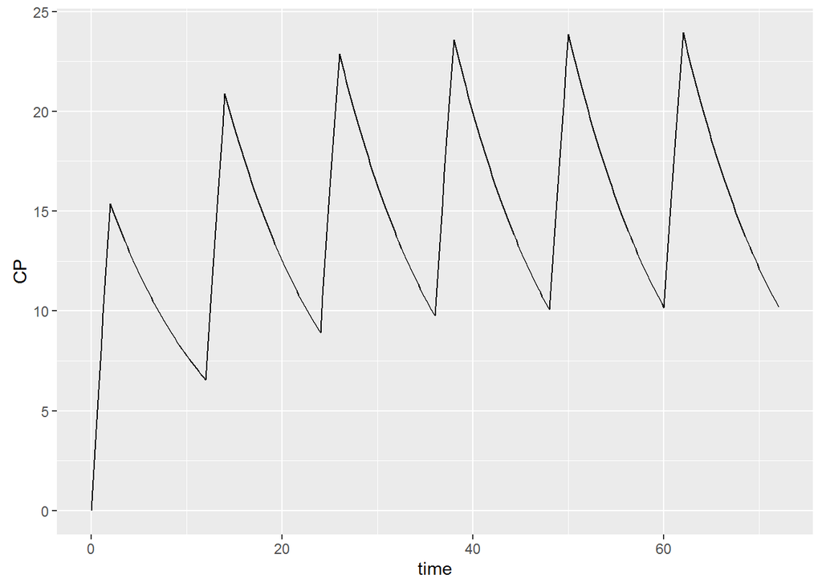

```r
infusion <- ev(amt=1000, rate = 500, ii=12, addl=12)

infusionsim <- mod %>% ev(infusion) %>% mrgsim(end = 72) %>%as.data.frame



ggplot(infusionsim, aes(x=time, y = CP)) + geom_line()
```

# Part 3 - compare dosing regimens

Important - avoid using rbind and iterative solutions to simulating. rbind requires generating a new df and copying old df’s to memory for each iteration.

Rather than Rbinding, grouping, etc, you can do this by specifying a more complex “event” using expand.ev()

**LOOK expand.ev()** is a very clean function to generate NONMEM type multiple dosing regimens. However - this will not work as intended. it generates an ID with unique dosing for every possible combination of values in vectors. I.E., below code generates 1000 QD and 2000 BID regimens which I do not want to include.

```r
multidose <- expand.ev(amt=c(1000,2000), rate=c(500), ii=c(12,24), addl=2)

head(as.data.frame(multidose))
```

```
##   ID  amt rate ii addl evid cmt time
## 1  1 1000  500 12    2    1   1    0
## 2  2 2000  500 12    2    1   1    0
## 3  3 1000  500 24    2    1   1    0
## 4  4 2000  500 24    2    1   1    0
```

Luckily this also allows “adding” of dosing regimens!

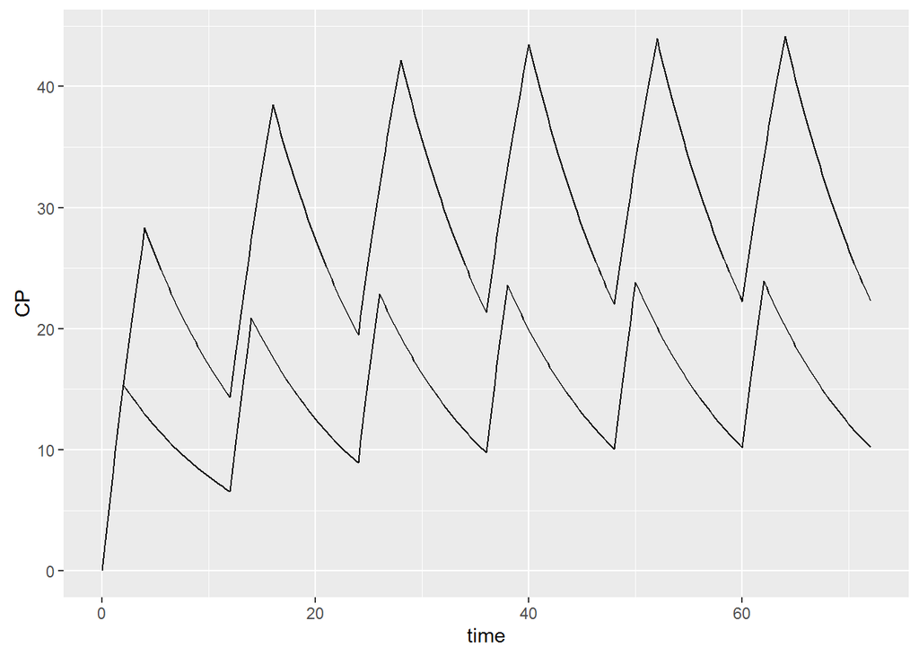

```r
q12h <- ev(amt= 1000, rate = 500, ID = 1, ii=12, addl = 12)

q24h <- ev(amt=2000, rate = 500, ID = 2, ii=12, addl=12)

both = q12h + q24h



multiregimen <- mod %>% ev(both) %>% mrgsim(end = 72) %>%as.data.frame



ggplot(multiregimen, aes(x=time, y = CP, group = ID)) + geom_line()
```

# Part 4 Population PK

CV of params: 100 patients, CL 30.13%; V1 22.83%

This requires changing the model completely. But it is nice to see where the math is coming from, i guess for a n00b. Added requirements to model -

```r
##We are required to update the model to include $OMEGA and $THETA.  This requires recompilation.

##OLD
cat(readLines("Vanco1cmpt.cpp"), sep="\n")
```

```
## $PARAM
## CL = 5.1, V = 59.86
##
## $CMT CENT
##
## $SET delta= 0.25
##
## $MAIN
##
## $ODE
## dxdt_CENT = - (CL/V)*CENT;
##
## double CP = CENT/V;
##
## $CAPTURE CP
```

```r
##NEW
cat(readLines("Vanco1cmptPOPPK.cpp"), sep="\n")
```

```
## $PARAM
## CL = 5.1, V = 59.86
##
## $CMT CENT
##
## $SET delta= 0.25
##
## $MAIN
##
## double CLi = exp(log(CL + ETA(1)));
## double VCi = exp(log(V + ETA(2)));
##
## $ODE
## dxdt_CENT = - (CLi/VCi)*CENT;
##
## $OMEGA 0 0
##
## $SIGMA 0
##
## $TABLE
##
## table(IPRED) = CENT/VCi;
## table(DV) = table(IPRED)*exp(EPS(1));
## table(ETA1)  = ETA(1);
##
## $CAPTURE CLi VCi
```

```r
modPOPPK <- mread('Vanco1cmptPOPPK')
```

```
## Compiling Vanco1cmptPOPPK.cpp.cpp ...
```

```
## done.
```

```
## Loading: Vanco1cmptPOPPKeac4a5d2527.dll
```

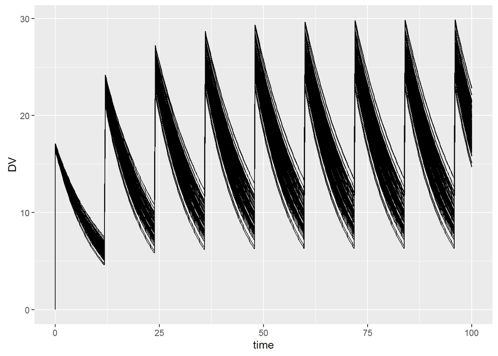

```r
## this takes a covariate n x n matrix as an input for omat

##not clear - order of params in matrix.  going to assume M_ij is the variance for ordered param i = j.  IE. CL is first named param in model so its variance is M(1,1).

##Create variance matrix.
cov = matrix(c(.3013, 0,0, .2283), 2,2)


popPK <- modPOPPK %>% ev(maint) %>% omat(cov) %>% mrgsim(nid = 100, end = 100) %>% as.data.frame

ggplot(popPK, aes(x=time, y = DV, group = ID)) + geom_line()
```

# Part 5